# brazilmaps na prática

Renato Prado Siqueira

```r
library(brazilmaps)
library(ggplot2)
```

O `brazilmaps` fornece malhas territoriais simplificadas como objetos `sf`. Todos os mapas usados abaixo são instalados com o pacote: nenhum exemplo depende de conexão com a internet.

Esta vignette apresenta um fluxo de trabalho completo, desde a escolha da divisão territorial até a construção de mapas temáticos. As geometrias são adequadas para visualização e análise exploratória, mas não para medições cadastrais ou decisões sobre limites legais.

## Escolher o nível territorial

`get_brmap()` usa nomes em *lower snake case*. Além do país, das grandes regiões e das unidades da federação, estão disponíveis regiões geográficas imediatas e intermediárias, municípios e duas divisões estatísticas descontinuadas pelo IBGE.

```r
levels <- c(
  "country", "region", "state",
  "intermediate_region", "immediate_region",
  "municipality", "mesoregion", "microregion",
  "state_hex", "state_region"
)

data.frame(level = levels)
```

```
#>                  level
#> 1              country
#> 2               region
#> 3                state
#> 4  intermediate_region
#> 5     immediate_region
#> 6         municipality
#> 7           mesoregion
#> 8          microregion
#> 9            state_hex
#> 10        state_region
```

O resultado padrão é um objeto `sf` em SIRGAS 2000 (EPSG:4674), pronto para uso com o ecossistema espacial do R.

```r
states <- get_brmap("state")

class(states)
```

```
#> [1] "sf"         "data.frame"
```

```r
sf::st_crs(states)$input
```

```
#> [1] "EPSG:4674"
```

```r
names(states)
```

```
#> [1] "state_code"         "name"               "state_abbreviation"
#> [4] "region_code"        "geometry"
```

Um mapa simples pode ser criado diretamente:

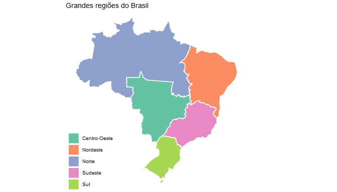

```r
regions <- get_brmap("region")

plot_brmap(
  regions,
  fill_by = "name",
  border_colour = "white",
  border_linewidth = 0.5
) +
  scale_fill_brewer(palette = "Set2") +
  labs(
    title = "Grandes regiões do Brasil",
    fill = NULL
  )
```

## Recortar a área de interesse

O argumento `filters` recebe uma lista nomeada de códigos territoriais. Quando há mais de uma condição, todas são aplicadas simultaneamente.

```r
pernambuco <- get_brmap(
  "municipality",
  filters = list(region = 2, state = 26)
)

unique(
  sf::st_drop_geometry(pernambuco)[c("region_code", "state_code")]
)
```

```
#>      region_code state_code
#> 1466           2         26
```

É possível sobrepor diferentes níveis porque todos usam o mesmo sistema de referência:

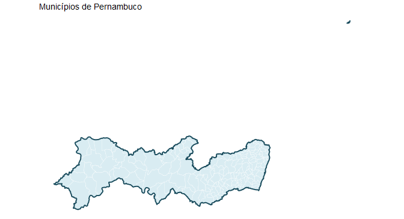

```r
pe_state <- get_brmap("state", filters = list(state = 26))

ggplot() +
  geom_sf(
    data = pernambuco,
    fill = "#d9ecf2",
    colour = "white",
    linewidth = 0.12
  ) +
  geom_sf(
    data = pe_state,
    fill = NA,
    colour = "#174a5b",
    linewidth = 0.65
  ) +
  labs(title = "Municípios de Pernambuco") +
  theme_brmap()
```

Os mesmos filtros podem selecionar outras divisões. Por exemplo, o código de uma região imediata pode ser obtido na DTB e usado para recortar sua malha:

```r
recife_hierarchy <- get_dtb(name = "Recife")
recife_hierarchy[
  recife_hierarchy$level == "municipality",
  c("municipality_name", "immediate_region_code", "immediate_region_name")
]
```

```
#>      municipality_name immediate_region_code immediate_region_name
#> 2935            Recife                260001                Recife
```

```r
recife_immediate <- get_brmap(
  "municipality",
  filters = list(
    immediate_region =
      recife_hierarchy$immediate_region_code[
        recife_hierarchy$level == "municipality"
      ][1]
  )
)
```

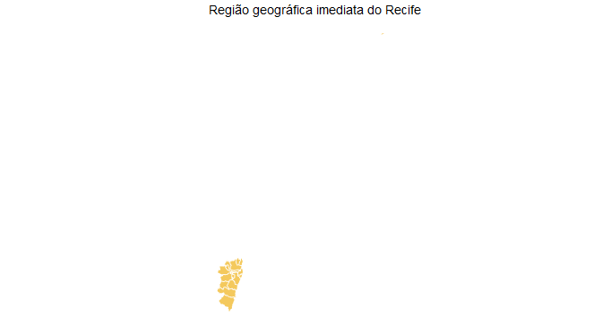

```r
plot_brmap(
  recife_immediate,
  fill = "#f4c95d",
  border_colour = "white",
  border_linewidth = 0.25
) +
  labs(title = "Região geográfica imediata do Recife")
```

## Juntar indicadores e criar mapas temáticos

`plot_brmap()` pode juntar uma tabela ao mapa durante a plotagem. O vetor nomeado em `by` informa a coluna do mapa à esquerda e a coluna dos dados à direita.

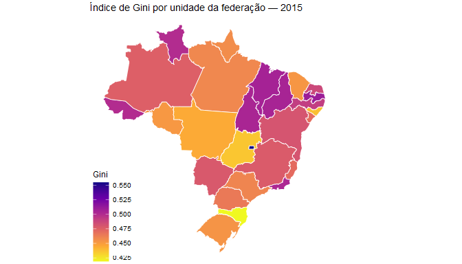

```r
data("gini2015")

plot_brmap(
  states,
  data = gini2015,
  by = c("state_code" = "cod"),
  fill_by = "gini",
  border_colour = "white",
  border_linewidth = 0.3
) +
  scale_fill_viridis_c(
    option = "C",
    direction = -1,
    na.value = "grey90"
  ) +
  labs(
    title = "Índice de Gini por unidade da federação — 2015",
    fill = "Gini"
  )
```

Para reutilizar os atributos acrescentados em outras operações, faça a junção explicitamente com `join_brmap()`. O objeto continua sendo `sf`.

```r
data("pop2017")

pe_population <- join_brmap(
  get_brmap(
    "municipality",
    year = 2023,
    filters = list(state = 26)
  ),
  pop2017,
  by = c("municipality_code" = "mun")
)

inherits(pe_population, "sf")
```

```
#> [1] TRUE
```

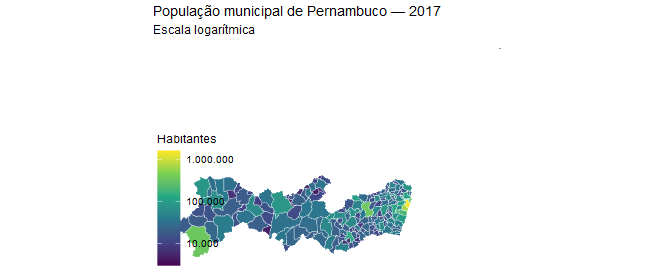

```r
plot_brmap(
  pe_population,
  fill_by = "pop2017",
  border_colour = "white",
  border_linewidth = 0.12
) +
  scale_fill_viridis_c(
    trans = "log10",
    labels = function(x) {
      format(
        x,
        big.mark = ".",
        decimal.mark = ",",
        scientific = FALSE,
        trim = TRUE
      )
    },
    na.value = "grey90"
  ) +
  labs(
    title = "População municipal de Pernambuco — 2017",
    subtitle = "Escala logarítmica",
    fill = "Habitantes"
  )
```

## Produzir um indicador a partir da hierarquia

`get_dtb_levels()` relaciona códigos e nomes de diferentes níveis da Divisão Territorial Brasileira. Aqui, a função é usada para contar municípios por unidade da federação e levar o resultado de volta ao mapa.

```r
municipality_state <- get_dtb_levels(c("municipality", "state"))

municipality_count <- aggregate(
  municipality_code ~ state_code,
  data = municipality_state,
  FUN = length
)
names(municipality_count)[2] <- "n_municipalities"

states_with_count <- join_brmap(
  states,
  municipality_count,
  by = "state_code"
)
```

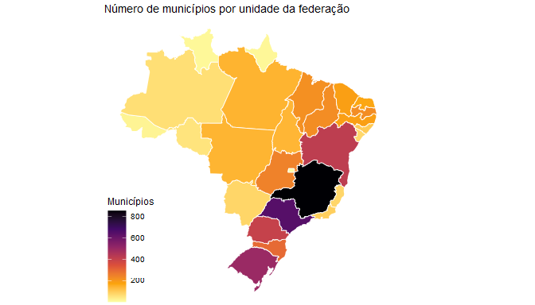

```r
plot_brmap(
  states_with_count,
  fill_by = "n_municipalities",
  border_colour = "white",
  border_linewidth = 0.3
) +
  scale_fill_viridis_c(option = "B", direction = -1) +
  labs(
    title = "Número de municípios por unidade da federação",
    fill = "Municípios"
  )
```

## Usar cartogramas

O pacote inclui duas representações alternativas das unidades da federação. `state_hex` atribui a mesma área visual a cada unidade, sendo útil quando estados pequenos precisam ter o mesmo destaque dos demais. `state_region` organiza as unidades em blocos que realçam sua grande região.

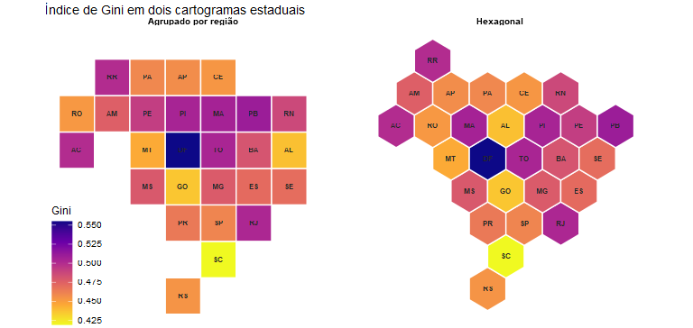

```r
state_attributes <- sf::st_drop_geometry(states)[
  c("state_code", "state_abbreviation")
]

state_hex <- join_brmap(
  get_brmap("state_hex"),
  state_attributes,
  by = "state_code"
)
state_hex$cartogram <- "Hexagonal"

state_region <- join_brmap(
  get_brmap("state_region"),
  state_attributes,
  by = "state_code"
)
state_region$cartogram <- "Agrupado por região"

state_cartograms <- rbind(state_hex, state_region)
state_cartograms <- join_brmap(
  state_cartograms,
  gini2015,
  by = c("state_code" = "cod")
)

cartogram_labels <- suppressWarnings(
  sf::st_point_on_surface(state_cartograms)
)
label_coordinates <- sf::st_coordinates(cartogram_labels)
cartogram_labels$x <- label_coordinates[, "X"]
cartogram_labels$y <- label_coordinates[, "Y"]
cartogram_labels <- sf::st_drop_geometry(cartogram_labels)

ggplot(state_cartograms) +
  geom_sf(
    aes(fill = gini),
    colour = "white",
    linewidth = 0.5
  ) +
  geom_text(
    data = cartogram_labels,
    aes(x = x, y = y, label = state_abbreviation),
    colour = "grey15",
    fontface = "bold",
    size = 2.1
  ) +
  facet_wrap(vars(cartogram), nrow = 1) +
  scale_fill_viridis_c(
    option = "C",
    direction = -1,
    na.value = "grey90"
  ) +
  labs(
    title = "Índice de Gini em dois cartogramas estaduais",
    fill = "Gini"
  ) +
  theme_brmap() +
  theme(
    strip.text = element_text(face = "bold"),
    panel.spacing = grid::unit(0.7, "lines")
  )
```

Os dois painéis usam exatamente a mesma variável e a mesma escala de cores. Para mapas geográficos convencionais, use `state`.

## Personalizar e exportar

`plot_brmap()` devolve um `ggplot`. Portanto, escalas, títulos, anotações, facetas e temas podem ser acrescentados normalmente.

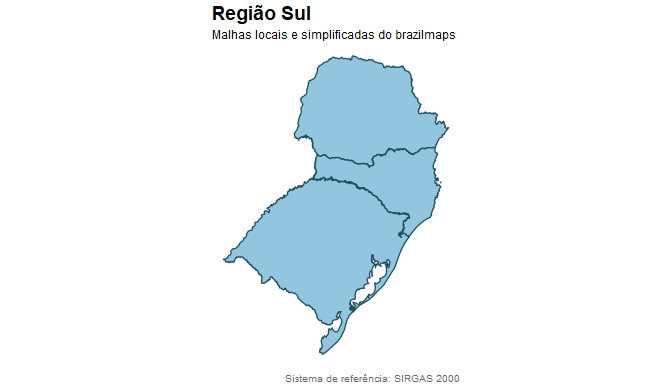

```r
map <- plot_brmap(
  get_brmap("state", filters = list(region = 4)),
  fill = "#92c5de",
  border_colour = "#1f4e5f",
  border_linewidth = 0.45
) +
  labs(
    title = "Região Sul",
    subtitle = "Malhas locais e simplificadas do brazilmaps",
    caption = "Sistema de referência: SIRGAS 2000"
  ) +
  theme(
    plot.title = element_text(face = "bold", size = 14),
    plot.caption = element_text(colour = "grey40")
  )

map
```

O objeto pode ser salvo com as funções usuais do `ggplot2`:

```r
ggsave(
  "regiao-sul.png",
  plot = map,
  width = 8,
  height = 6,
  dpi = 300
)
```

## Malhas municipais históricas

O ano mais recente é usado por padrão. As edições municipais instaladas podem ser consultadas com `brmap_editions()` e selecionadas pelo argumento `year`.

```r
brmap_editions()[c("year", "n_features")]
```

```
#>   year n_features
#> 1 2000       5508
#> 2 2001       5561
#> 3 2007       5564
#> 4 2010       5565
#> 5 2023       5570
#> 6 2025       5571
```

```r
goias_2000 <- get_brmap(
  "municipality",
  year = 2000,
  filters = list(state = 52)
)
```

Para critérios de seleção das edições, comparações temporais e limitações da classificação histórica, consulte a vignette `vignette("historical-municipal-meshes", package = "brazilmaps")`.